# Understanding the Role of T cell Activity in Generating the Neurodevelopmental Consequences Associated with Maternal Infection

A Four Month Update

Nick Fox

Tuesday, March 03, 2015

# **Summary**

## *Research Aim 1*

Assess the effect the effect of T cell-specific maternal immune activation on the generation of schizophrenic-associated behavioral deficits in adult progeny.

### **Methods**

#### Animals

Experiments for Aim 1 were conducted using C57BL/6 mice bred in our vivarium (Psychology Building, Busch Campus, Rutgers University New Jersey). Animals were housed 3-4 per cage with siblings of the same sex under a 12:12h light:dark cycle (lights on at 5:30a). Food and water was available ad libitum. All experiments were conducted in accordance with the Guide for the Care and Use of Laboratory Animals as adopted by the National Institutes of Health, and approved by the Rutgers Institutional Animal Care and Use Committee.

#### Animal Breeding

Pregnant females were generated by housing two females with one male. Females were checked daily for the presence of a sperm plug, which was evidence of copulaltion. The day a sperm plug was identified was considered embryonic day 0.5 (E0.5). Females observed with a sperm plug were removed from the breeding cage and singly housed. Regardless of sperm plug, body weight was measured twice a week for evidence of developing pregnancy. Females with progressively increasing body weight were singly housed before birth.  
Pregnant females gave birth between E20 and E21. Pups were weaned from their mother on postnatal day 21 (PN21), with weekly cage changes. On PN21, pups will be sexed and housed with same sex siblings in new cages.

#### Staphylococcal Enterotoxin A Administration

Three pregnant females were injected intraperitoneally (IP) with 200ug/kg of staphylococcal enterotoxin A (SEA) in 200ul on day E12.5. Another three pregnant females were IP injected with 200ul physiological saline and acted as control animals.

#### Behavioral Measures

##### Four Platform Water Radial Arm Maze

I replaced the proposed Morris Water Maze (MWM) task with the four platform water radial arm maze (4wRAM) after a recent publication by Vorhees and Williams (2014) suggested the wRAM was a more sensitive tool for investigating teratogenic effects. This maze consists of eight arms radiating from a central hub. The entire maze is filled with 22C water and made opaque with white tempera paint. The maze exists in an environment rich in spatial cues. Four platforms are submerged 1-2cm below the surface of the water in four different arms. No more than two adjcent arms may contain platforms. Animals are run for four trials per day for a total of 12 days. Animals start at the end of one arm and are allowed to explore the maze for 120 seconds. When they find a platform, the trial is ended, the animal is taken out of the maze, as is the platform they found. After a 45 second inter-trial interval, the animal is returned to the maze (now with only three platforms), and again allowed to explore for 120 seconds. Trials 3 and 4 follow, with only one platform existing in the maze in the last trial.

The outcome from this task is measured by two types of errors: Working Memory Correct (WMC) errors, and Reference Memory (RM) errors. A WMC error is an entry into an arm that had been previously used to escape the maze. A RM error is an entry into an arm that had never had a platform.

##### Single Platform Radial Arm Maze

I also used a single platform radial arm maze (1wRAM) to more directly test spatial learning as in the traditional MWM. This maze uses the same apparatus as the 4wRAM, though only has one platform. This platform remains in the same arm for all trials. Animals are run for four trials per day for a total of 8 days. On each trial, the animal starts in a randomized arm and is allowed to explore the maze for 60 seconds. When the animal finds the platform, the trial ends and the animal is removed from the maze.

The outcomes from this task are distance traveled, measured in meters, and latency to find the platform, measured in seconds.

##### Prepulse Inhibition

A behavioral model of prepulse inhibition designed for mice was utilized. Each animal was placed into a Colburn Instruments acoustic startle chamber. The chamber includes an acrylic tube (to contain the animal) which is mounted on an acrylic plate, under which is attached an accelerometer. The accelerometer measures the inflection of the animal/tube in response to acoustic stimulation. White noise was transmitted to the box via a speaker in the top of the chamber. Pulses of white noise was 120db. This pulse is intended to cause a starte. We had three levels of our prepulse, either 62db, 65db, or 68db (+2db, +5db, and +8db above background). Each pulse lasted for 40ms.

For “pulse alone” trials (S), only 40ms of the 120db white noise was provided. Inflection from this trial served as a positive control for startle. “Prepulse alone” trials (p) only consisted of 40ms of one of the three prepulse conditions and served as a negative control (prepulse tones should not be inherently startling, and we saw that they were not). Test trials (PPI-S) had both prepulse and pulse, separated by an inter-pulse interval of 100ms. Animals were exposed to 30 PPI-S trials, 15 S trials, and 15 p trials, randomly ordered. Each session began and ended with five S trials.

Percent scores for amount prepulse inhibition were calculated as %PPI = 100 * (S - PPI-S) / S. Scores closer to 0% were considered evidence of less prepulse inhibition.

#### **Results**

##### Four Platform Working Memory

The learning curve, measured by WMC errors is shown in Figure 1, and the learning curve measured by RM errors is shown in Figure 2.

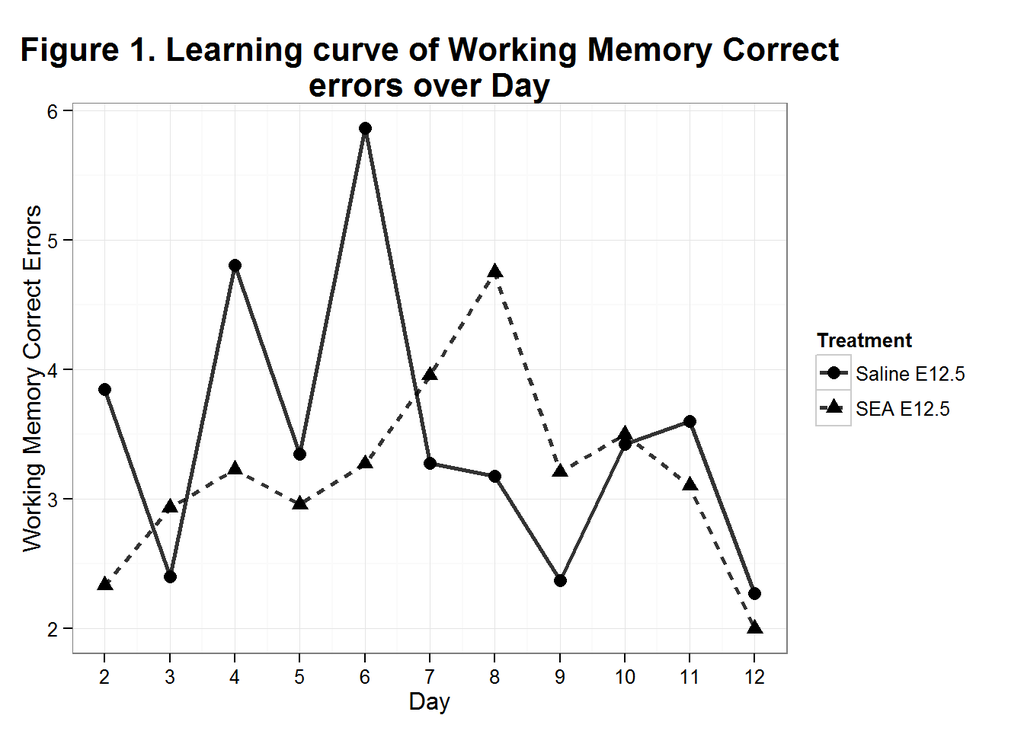

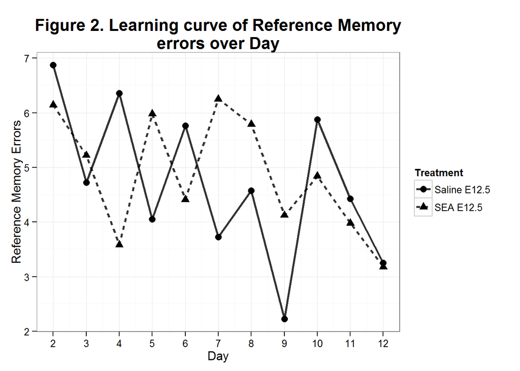

One-between (treatment) and one-within (Day) repeated measures ANOVAs revealed a main effect of Treatment for Working Memory Correct errors (F(1, 257) = 5057, p < 0.05), but not for Reference Memory errors (F(1, 257) = 0.98, p > 0.05). We found a significant main effect of Day for Reference Memory errors (F(1, 257) = 16.36, P < 0.001), but not for Working Memory Correct errors (F(1, 257) = 0.06, p > 0.05). We did not detect an interaction between Treatment and Day in our collected data.

To further investigate the learning curves, we analyzed the data trial-by-trial. Figure 3 shows the mean number of WMC errors by trial across days, and figure 4 shows the mean number of RM errors.

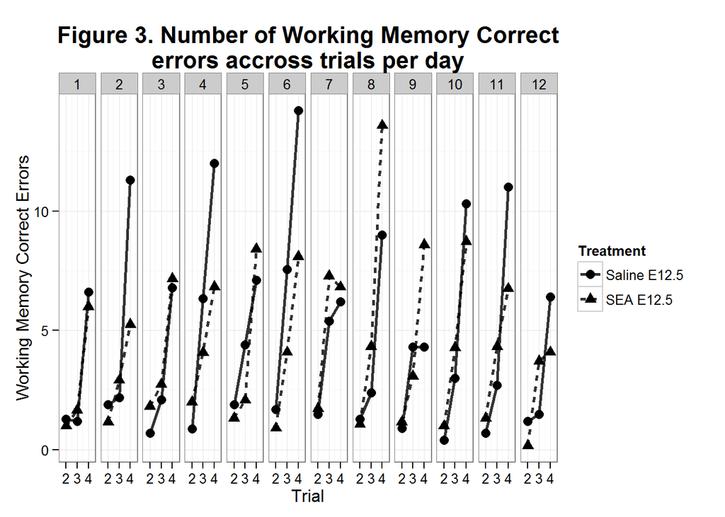

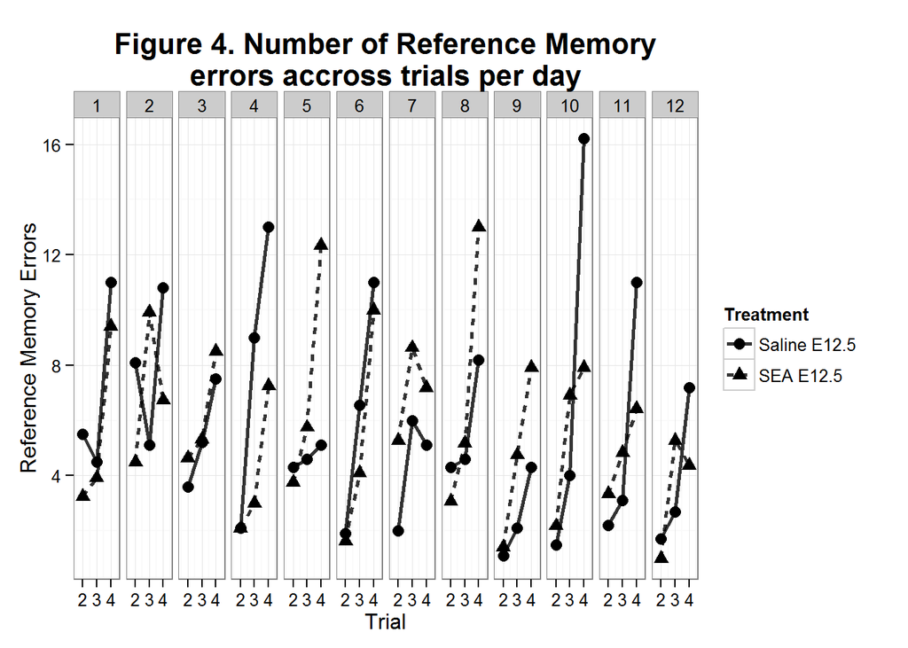

Animals make significantly more WMC errors (F(1, 92) = 265.78, p < 0.001) and RM errors (F(1, 92) = 121.51, p < 0.001) on trial 4 of a test day.

##### Single Platform Spatial Navigation

To investigate if our animals from treated mothers were able to learn to spatially navigate the wRAM using extramaze cues, we tested a 33 animals (22 males, 11 females) in the single platform water radial arm maze. Males and females were run in two separate experiments and are reported separately.

**Males**.  
The average distance traveled by males before finding the escape platform is shown in Figure 5.

[figure not shown]

We found a main effect of Day (F(1, 149) = 70.32, p < 0.001), but not for Treatment (F(1, 149) = 2.09, p > 0.05) on the distance traveled before finding the escape platform.

The average latency for males to find the escape platform is shown in Figure 6.

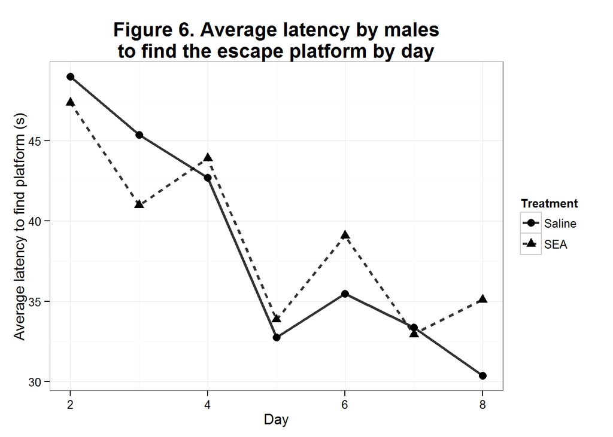

We found a main effect of Day (F(1, 149) = 12.32, p < 0.001), but not for Treatment (F(1, 149) = 1.49, p > 0.05) on the latency to find the escape platform.

**Females**.  
The average distance traveled by females before finding the escape platform is shown in Figure 7.

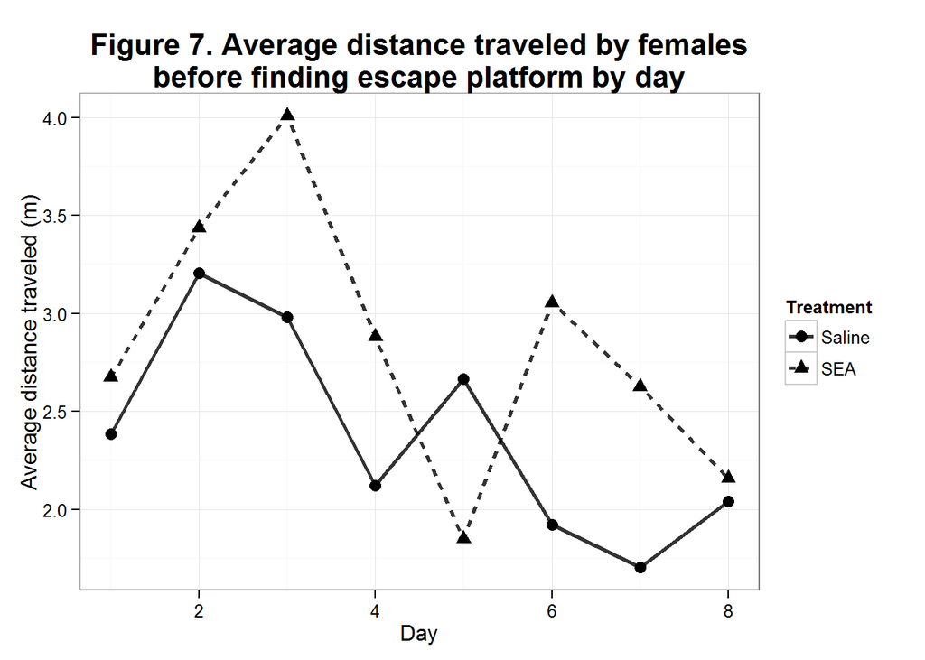

We found a main effect of Day (F(1, 83) = 7.37, p < 0.01), and a marginally significant main effect of Treatment (F(1, 83) = 3.69, p = 0.058) on the distance traveled before finding the escape platform.

The average latency for females to find the escape platform is shown in Figure 8.

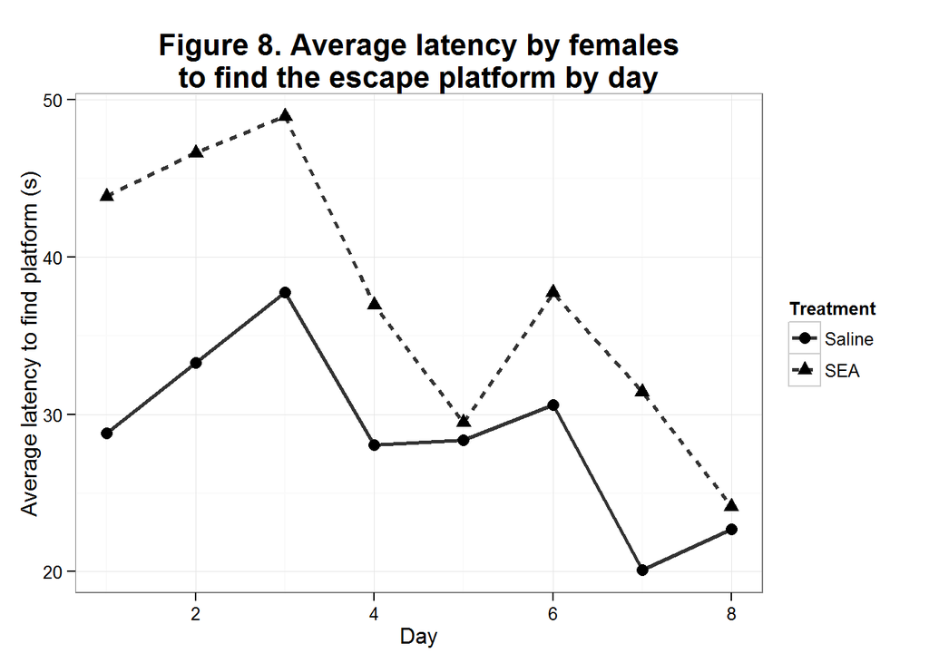

We found a main effect of Day (F(1, 83) = 12.76, p < 0.001), and a main effect of Treatment (F(1, 83) = 6.5, P < 0.05) on the latency to find the escape platform.

## Research Aim 2

Assess the ability of T cell-specific maternal immune activation to sensitize progeny to repeated psychological stress in adolescence.

### Additional Methods

Methods of animal care, breeding, and SEA administration will remain as stated under Research Aim 1. Additional methods unique to Research Aim 2 follow below.

#### Chronic Psychological Stress

Psychological stress will be administered starting postnatal day 28 (PN28), or one week after weaning. Randomized stressors will be administered daily for fifteen weekdays. Animals will not be stressed over weekends. Stressors included are as follows:

1. four hours of restraint
2. two hours of exposure to foot shock chamber
- 10 foot shocks are administered at unpredictible intervals over the two hour period
3. two hours of exposure to whote noise chamber
- 40 bursts of white noise at randomized frequency and duration are administered over the two hour period
4. social disruption
- individual animals are introduced to a new cage with two long-term cagemates
5. circadian cycle disruption
- individuals are singly housed in a bright room overnight, robbing them of a dark phase that day.

This is the first pass at analyzing the wRAM working memory protocol in R. Things to do:  
Methods:  
6) Elevated Plus Maze  
7) Open Field / Novel Object

Results:  
- low-grade chronic stress: body weight, EPM, OF, PPI  
- severe chronic stress: body weight, EPM, OF, PPI  
Future plans